# HICP Forecasting for Norway (2010-2021)

Renuka Nair

Loading the data for HICP of basket goods (sugar, honey, jam and other confectionary)in Norway 2010-2021

```r
library(fpp)
library(fpp2)
library(TTR)

HICP_Norway <- read.csv("C:/Users/Renuka/Downloads/HICP_Norway.csv")
```

```r
class(HICP_Norway)
```

```
[1] "data.frame"
```

Converting the dataset into a time series for forecasting

```r
hicp_ts <- ts (HICP_Norway$HICP, frequency =12, start=c(2010,1))
hicp_ts
```

```
       Jan   Feb   Mar   Apr   May   Jun   Jul   Aug   Sep   Oct   Nov   Dec
2010  96.4  99.3  98.2  98.6  96.6  97.5  98.4  99.6  97.4  96.2  96.4  93.7
2011  92.5  95.6  95.1  92.6  92.2  92.6  93.6  91.2  93.1  91.1  93.2  90.2
2012  92.5  94.7  93.8  92.7  91.8  93.1  92.3  90.4  91.9  90.8  92.5  89.1
2013  91.3  93.0  91.8  94.1  93.5  92.8  94.9  94.9  94.4  94.9  93.8  91.2
2014  94.0  94.7  94.8  92.9  95.8  93.8  97.6  96.7  96.4  96.2  98.1  93.3
2015  96.8 100.7  99.0  98.0  99.2 101.3 103.5 102.4 102.5 100.8 101.9  93.9
2016 101.2 105.3  95.1 103.1 102.8 103.1 105.5 105.5 103.5 103.0 103.9  96.0
2017 100.4 102.7 101.8  98.3 102.0 102.9 105.7 101.7 100.1 100.2  99.1  95.9
2018 105.2 106.6 102.3 103.3 105.6 106.1 108.1 105.4 105.8 103.9 106.8 102.8
2019 104.1 107.9 106.5 103.0 102.6 101.9 105.7 101.3 100.9  99.2 101.9  96.6
2020 103.8 107.6 105.7 106.4 105.7 105.1 108.9 106.1 107.0 105.7 106.8 100.3
2021 101.9 102.1 100.0  99.3  98.4  97.2  98.7  97.8
```

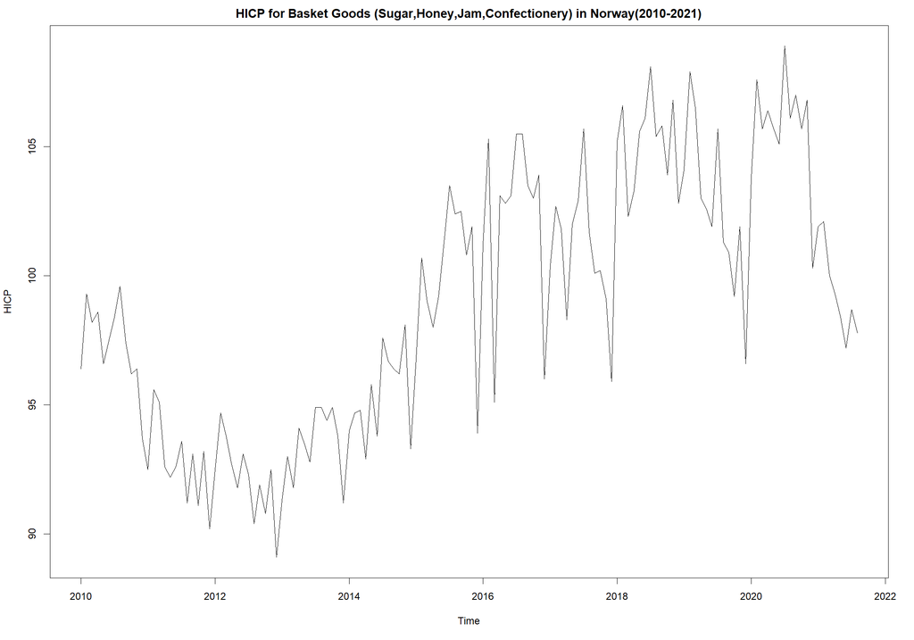

```r
plot (hicp_ts, main="HICP for Basket Goods (Sugar,Honey,Jam,Confectionery) in Norway(2010-2021)",ylab="HICP")
```

Summary of the time series data :

```r
summary(hicp_ts)
```

```
   Min. 1st Qu.  Median    Mean 3rd Qu.    Max.
  89.10   94.33   98.85   98.92  103.00  108.90
```

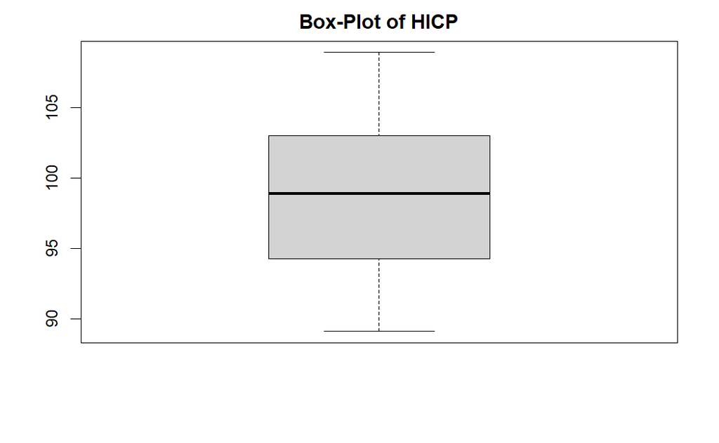

```r
boxplot(hicp_ts,main="Box-Plot of HICP")
```

## Data Exploration and Preparation

We can see from the time series graph that around the year 2013, there was a dip and post this, we can see a steady increase in the indexes and gradually settling towards the end of 2020 and 2021. This could be due to a fundamental change in the way these goods are priced and thus, for the sake of considering most relevant data for forecasting, we will include the data from 2014 onwards as that would yield a more accurate forecast.

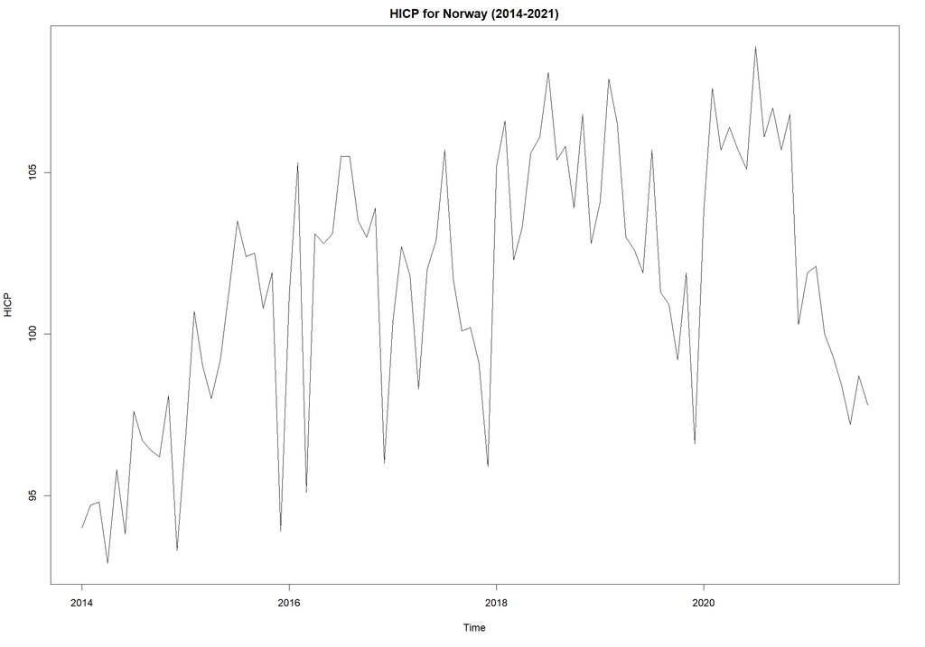

```r
hicp_ts_recent <- window(hicp_ts,start=c(2014,01))
plot(hicp_ts_recent,main="HICP for Norway (2014-2021)",ylab="HICP")
```

We have now cut off the part of data that is no longer relevant to our forecast. We can see the changes in our mean and median after cutting down the historical data.

```r
summary(hicp_ts_recent)
```

```
   Min. 1st Qu.  Median    Mean 3rd Qu.    Max.
  92.90   98.62  101.95  101.53  105.22  108.90
```

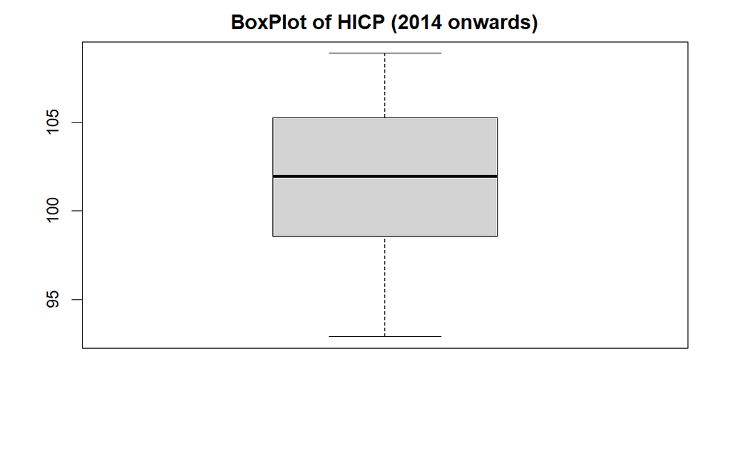

```r
boxplot(hicp_ts_recent,main="BoxPlot of HICP (2014 onwards)")
```

Comparing the ACF of both time series, we can now see how the seasonality seems to be more pronounced in the new reduced dataset as compared to that in the older dataset.

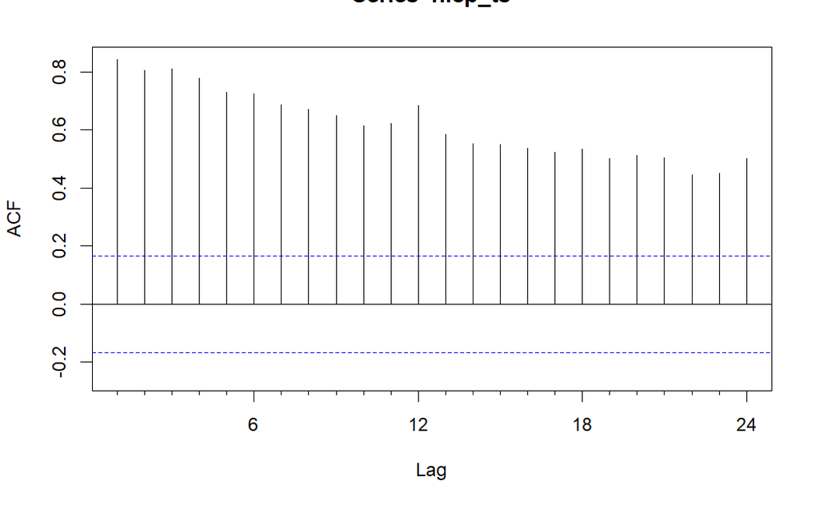

```r
Acf(hicp_ts)
```

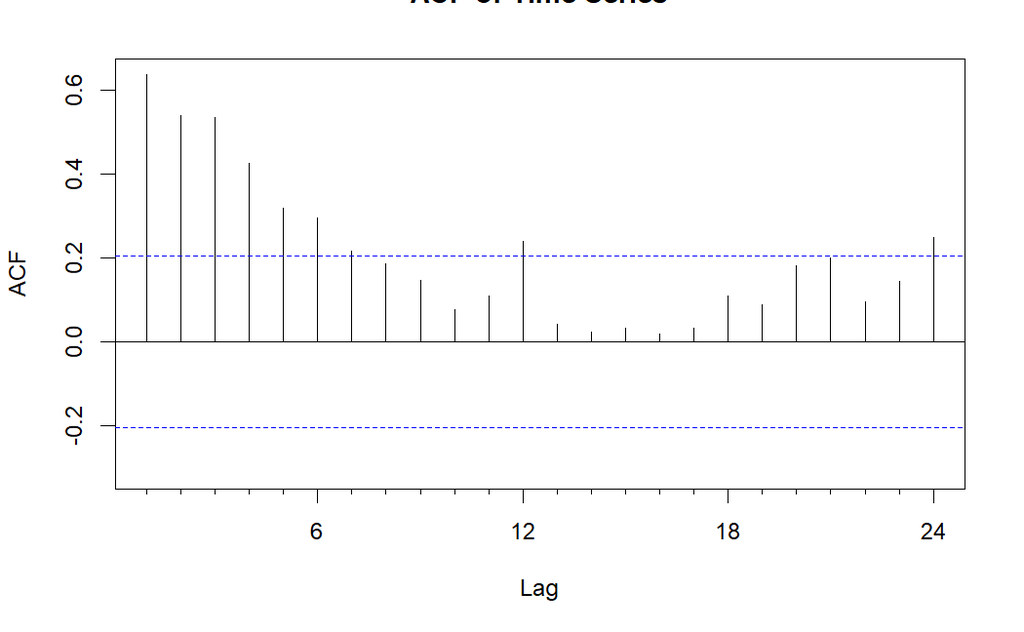

```r
Acf(hicp_ts_recent, main="ACF of Time Series")
```

## Decomposition

Decomposition helps us understand if the data has a significant seasonality component. If yes, we can see how the seasonality affects the data.

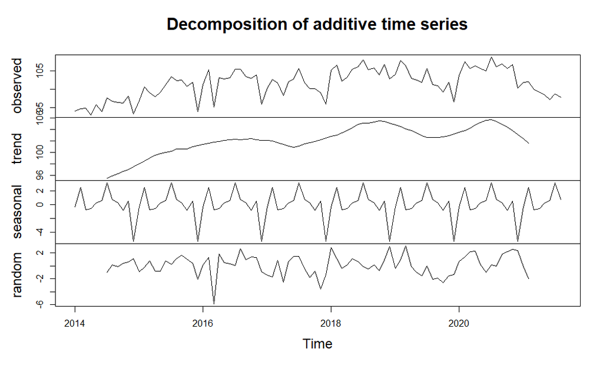

```r
decomp_hicp <- decompose(hicp_ts_recent)
plot(decomp_hicp)
```

We can see here that the seasonality component is minuscule. The noise factor is more pronounced than the seasonality component and thus we can say that the data is not affected much by seasonality. But if we look at the data in general, we can see the index value dips a little every December. This could be attributed to the festive season and how the prices of sugar, jam, honey and other confectionery items are directly affected by it.

To drive this point home, lets take a look at the monthly indices to see how seasonality is pulling the HICP up or down.

```r
decomp_hicp$type
```

```
[1] "additive"
```

```r
round(decomp_hicp$figure/10,2)
```

```
 [1] -0.03  0.24 -0.08 -0.06  0.02  0.05  0.31  0.07  0.03 -0.08  0.05 -0.52
```

As we speculated, the seasonality is pretty much insignificant except in Dec where we can see it pulling down the HICP.

Lets try seasonally adjusting the data to see how different it could be from the data at hand.

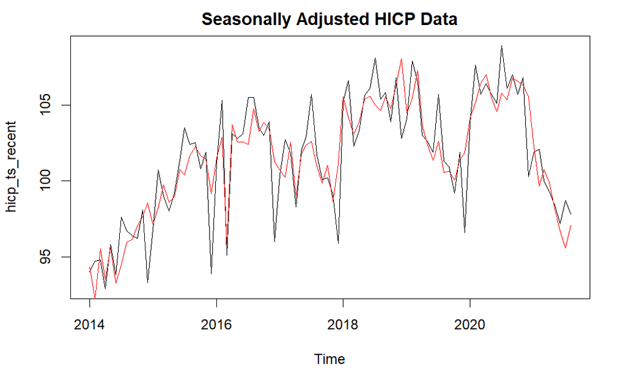

```r
hicp_seas_adj <- seasadj(decomp_hicp)
plot(hicp_ts_recent, main="Seasonally Adjusted HICP Data")
lines(hicp_seas_adj,col="Red")
```

## Forecasting

### Mean Forecast

We start with the simplest of forecast first which is mean forecast that simply takes the average of the observations and forecasts the value

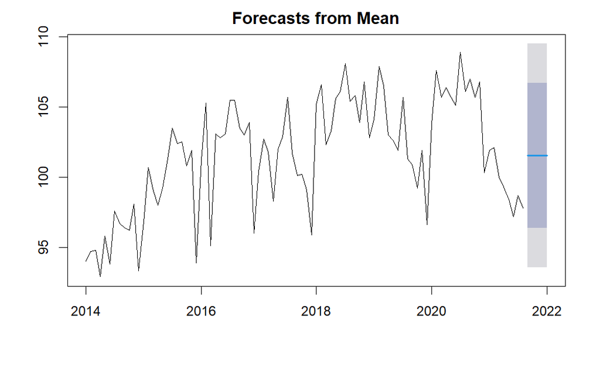

```r
mean_forecast <- meanf(hicp_ts_recent,5)
plot (mean_forecast)
```

```r
mean_forecast$mean
```

```
          Jan Feb Mar Apr May Jun Jul Aug      Sep      Oct      Nov      Dec
2021                                      101.5337 101.5337 101.5337 101.5337
2022 101.5337
```

### Naive Forecast

Naive Forecasting principle considers the latest data points to be most relevant. It takes the last data point and predicts the same value over the forecasting period. Obviously, this wouldn’t work well in case of data that have seasonality. But it can be taken as a benchmark to compare other model’s performance.

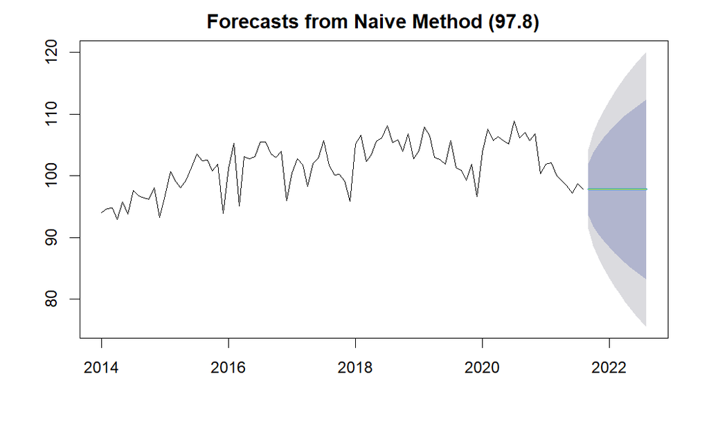

```r
hicp_naive <- naive(hicp_ts_recent,12)
plot(hicp_naive, main='Forecasts from Naive Method (97.8)')
lines(hicp_naive$mean,col="yellow")
```

#### Residual Analysis for Naive

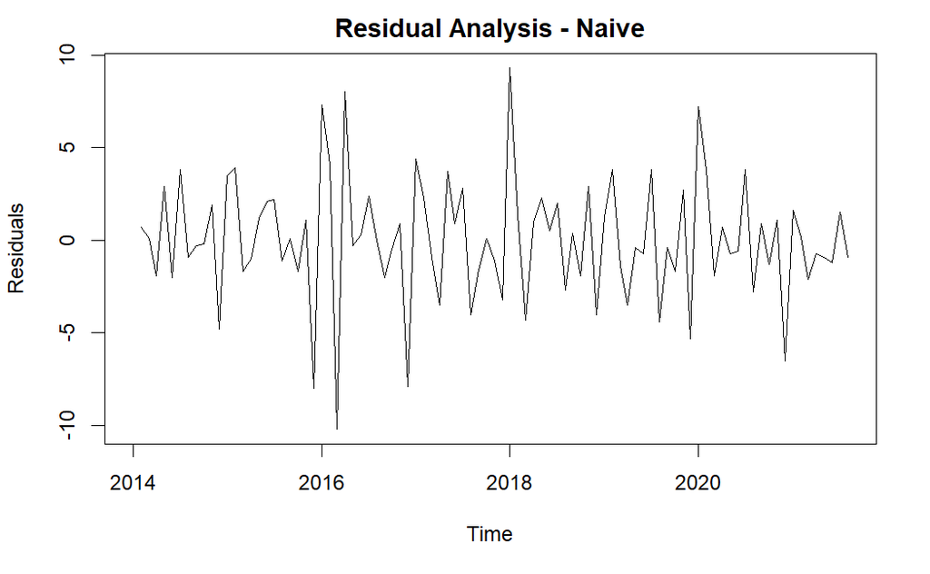

```r
plot(hicp_naive$residuals,main="Residual Analysis - Naive",ylab="Residuals")
```

ACF of Naive model residuals shows some significant correlation in residuals at Lag 12 and 24. This is expected as we know that there is a seasonal dip happening in Dec every year which the Naive model is not taking into account.

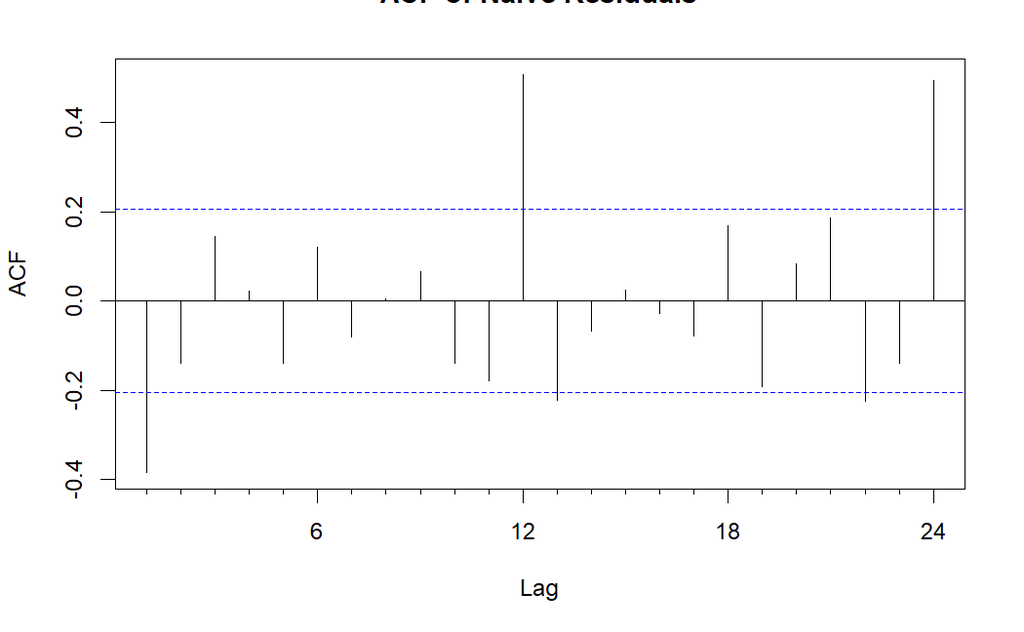

```r
Acf(hicp_naive$residuals,main="ACF of Naive Residuals")
```

Residual Vs Actual Plot

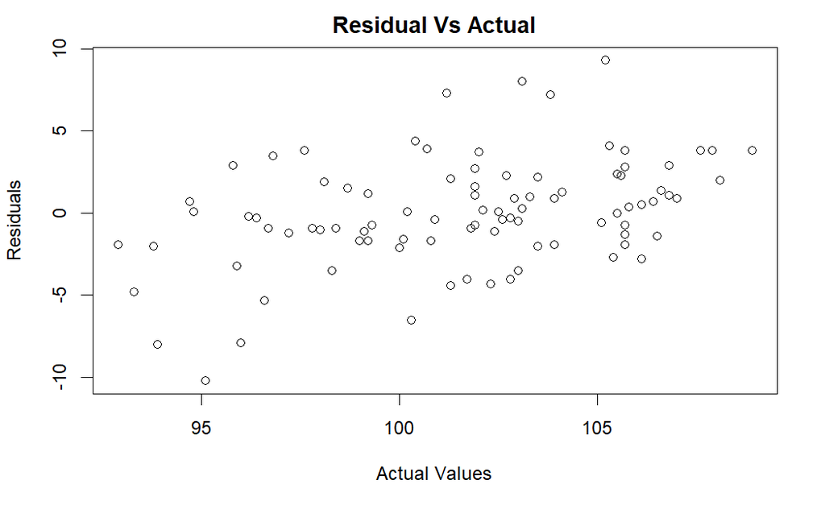

```r
plot(hicp_naive$x,hicp_naive$residuals,xy.labels=FALSE,xy.lines = FALSE,xlab="Actual Values",ylab="Residuals", main="Residual Vs Actual")
```

Residual Vs Fitted Plot

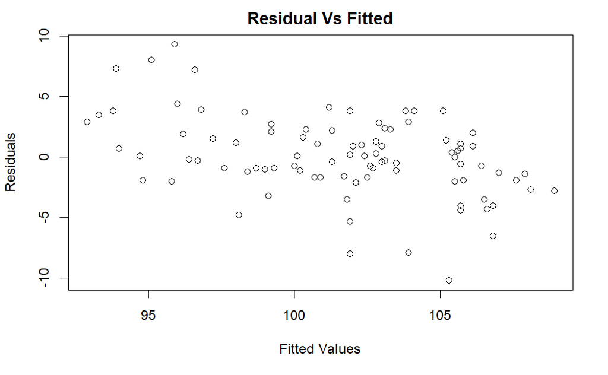

```r
plot(hicp_naive$fitted,hicp_naive$residuals,xy.labels=FALSE,xy.lines = FALSE,xlab="Fitted Values",ylab="Residuals",main="Residual Vs Fitted")
```

Residual Histogram Plot

We can see that the residuals show a fairly normal distribution slightly skewed to the right. So the naive method seems to be underforecasting.

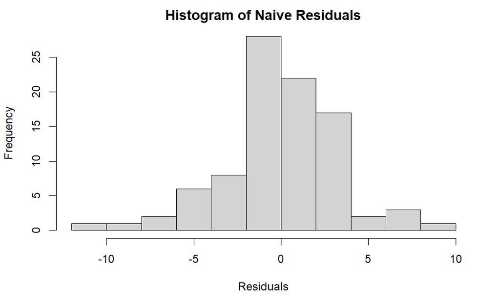

```r
hist(hicp_naive$residuals, main="Histogram of Naive Residuals",xlab="Residuals")
```

```r
forecast(hicp_naive)
```

|  | Point Forecast | Lo 80 | Hi 80 | Lo 95 | Hi 95 |
| --- | --- | --- | --- | --- | --- |
| Sep 2021 | 97.8 | 93.59444 | 102.0056 | 91.36815 | 104.2319 |
| Oct 2021 | 97.8 | 91.85244 | 103.7476 | 88.70399 | 106.8960 |
| Nov 2021 | 97.8 | 90.51575 | 105.0842 | 86.65971 | 108.9403 |
| Dec 2021 | 97.8 | 89.38888 | 106.2111 | 84.93630 | 110.6637 |
| Jan 2022 | 97.8 | 88.39608 | 107.2039 | 83.41794 | 112.1821 |
| Feb 2022 | 97.8 | 87.49852 | 108.1015 | 82.04525 | 113.5548 |
| Mar 2022 | 97.8 | 86.67313 | 108.9269 | 80.78292 | 114.8171 |
| Apr 2022 | 97.8 | 85.90488 | 109.6951 | 79.60798 | 115.9920 |
| May 2022 | 97.8 | 85.18332 | 110.4167 | 78.50445 | 117.0956 |
| Jun 2022 | 97.8 | 84.50085 | 111.0992 | 77.46070 | 118.1393 |

[output cut: 2 more lines]

#### Accuracy Measures

For this particular project, we would focus on the RMSE as an accuracy measure. This is because forecasting HICP requires high precision as many key economical decisions are made based on the trend seen in HICP. As RMSE would penalise us for any error in prediction (since it is squaring up the error), we think this is the best accuracy measure for this particular project.

```r
a_n<-accuracy(hicp_naive)
a_n
```

```
                     ME     RMSE     MAE          MPE     MAPE      MASE       ACF1
Training set 0.04175824 3.281617 2.43956 -0.009851831 2.415338 0.6313971 -0.3843648
```

As we can see, the RMSE for Naive is not that great as there is much more information that needs to be utilised by the model to give out better prediction.

### Seasonal Naive Forecast

Seasonal Naive takes the effects of seasonality into account while forecasting and is an improvement over Naive method when forecasting with seasonal data.

```r
snaive_forecast <- snaive(hicp_ts_recent,12)
plot(snaive_forecast)
lines(snaive_forecast$mean,col="pink")
```

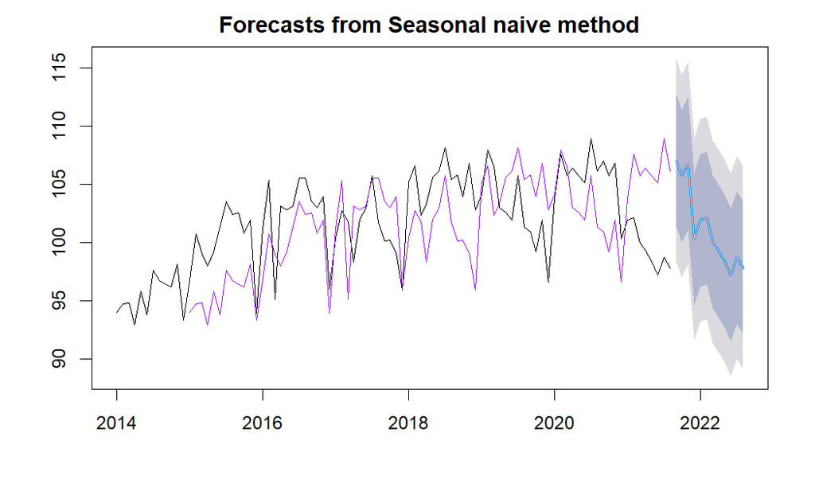

```r
lines(snaive_forecast$fitted,col="purple")
```

We can see that seasonal naive is not that great at forecasting either as the error in forecasting seems quite huge at places.

### Exponential Smoothing

Exponential smoothing breaks down the data into its components such as seasonality, trend and noise.

```r
hicp_ets <- ets(hicp_ts_recent)
summary(hicp_ets)
```

```
ETS(A,Ad,A)

Call:
 ets(y = hicp_ts_recent)

  Smoothing parameters:
    alpha = 0.6337
    beta  = 1e-04
    gamma = 1e-04
    phi   = 0.9474

  Initial states:
    l = 93.9623
    b = 0.4439
    s = -5.244 0.4416 -0.866 0.3362 0.8946 3.1326
           0.4067 0.3043 -0.6567 -0.6168 2.2718 -0.4045

  sigma:  1.9873

     AIC     AICc      BIC
559.5744 568.9443 604.9666

Training set error measures:
                      ME     RMSE      MAE        MPE     MAPE      MASE        ACF1
Training set -0.08966673 1.794307 1.375361 -0.1109913 1.363334 0.3559654 -0.03547928
```

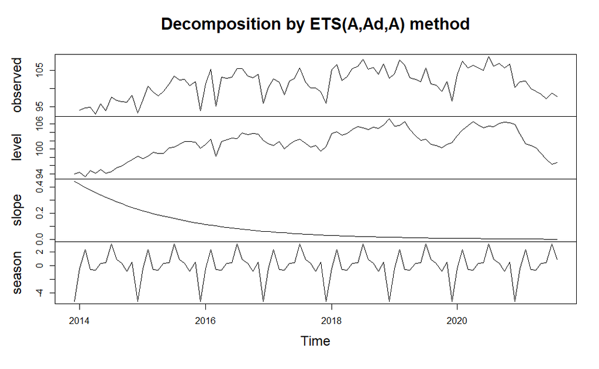

```r
plot(hicp_ets)
```

From the summary we can see that the data shows additive errors, additive trend and additive seasonality.

Mean Squared Error for ets model can be given as :

```r
hicp_ets$mse
```

```
[1] 3.219537
```

Forecasting can be done by :

```r
forecast_ets <- forecast.ets(hicp_ets, h=12)
forecast_ets
```

|  | Point Forecast | Lo 80 | Hi 80 | Lo 95 | Hi 95 |
| --- | --- | --- | --- | --- | --- |
| Sep 2021 | 97.02262 | 94.47581 | 99.56943 | 93.12761 | 100.91762 |
| Oct 2021 | 95.82236 | 92.80711 | 98.83761 | 91.21093 | 100.43379 |
| Nov 2021 | 97.13167 | 93.71143 | 100.55190 | 91.90087 | 102.36246 |
| Dec 2021 | 91.44776 | 87.66557 | 95.22995 | 85.66340 | 97.23212 |
| Jan 2022 | 96.28891 | 92.17642 | 100.40141 | 89.99940 | 102.57843 |
| Feb 2022 | 98.96645 | 94.54820 | 103.38469 | 92.20933 | 105.72357 |
| Mar 2022 | 96.07947 | 91.37524 | 100.78369 | 88.88497 | 103.27396 |
| Apr 2022 | 96.04084 | 91.06699 | 101.01469 | 88.43400 | 103.64769 |
| May 2022 | 97.00315 | 91.77351 | 102.23279 | 89.00510 | 105.00120 |
| Jun 2022 | 97.10667 | 91.63313 | 102.58021 | 88.73561 | 105.47773 |

[output cut: 2 more lines]

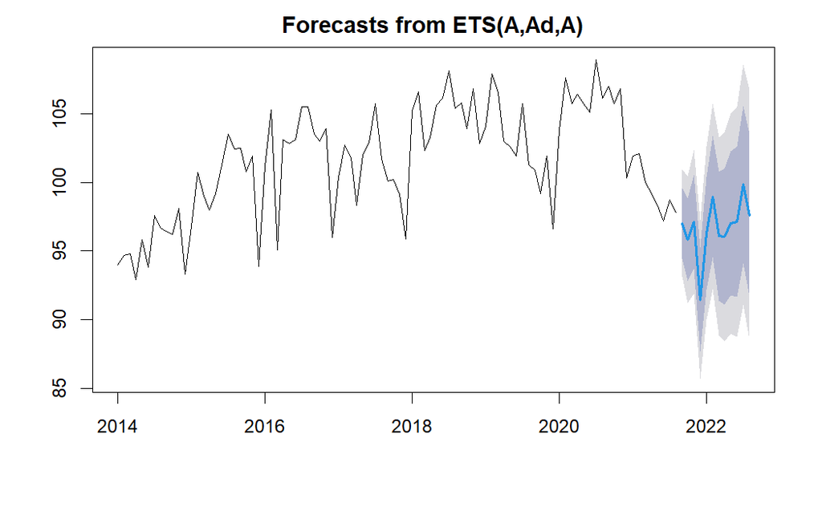

```r
plot(forecast_ets)
```

#### Residual Analysis of ETS

Histogram of Residuals

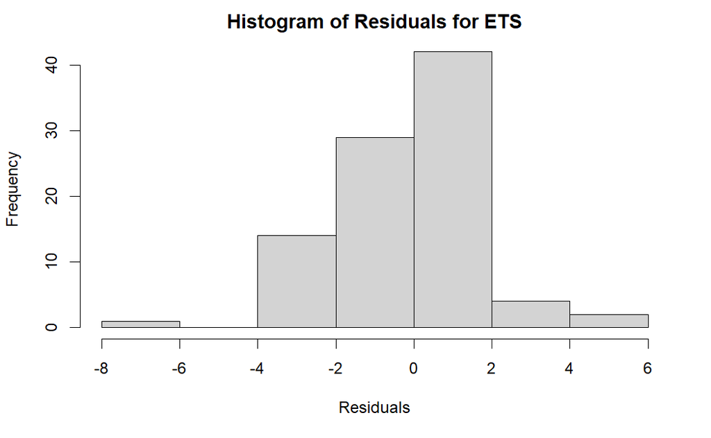

```r
hist(forecast_ets$residuals, main="Histogram of Residuals for ETS",xlab="Residuals")
```

Similar to Naive, we can see that the residuals are fairly normally ditributed. But as opposed to Naive, we are seeing the histogram skewed to the left meaning our ETS is overforecasting the HICP.

Plot and ACF of Residuals

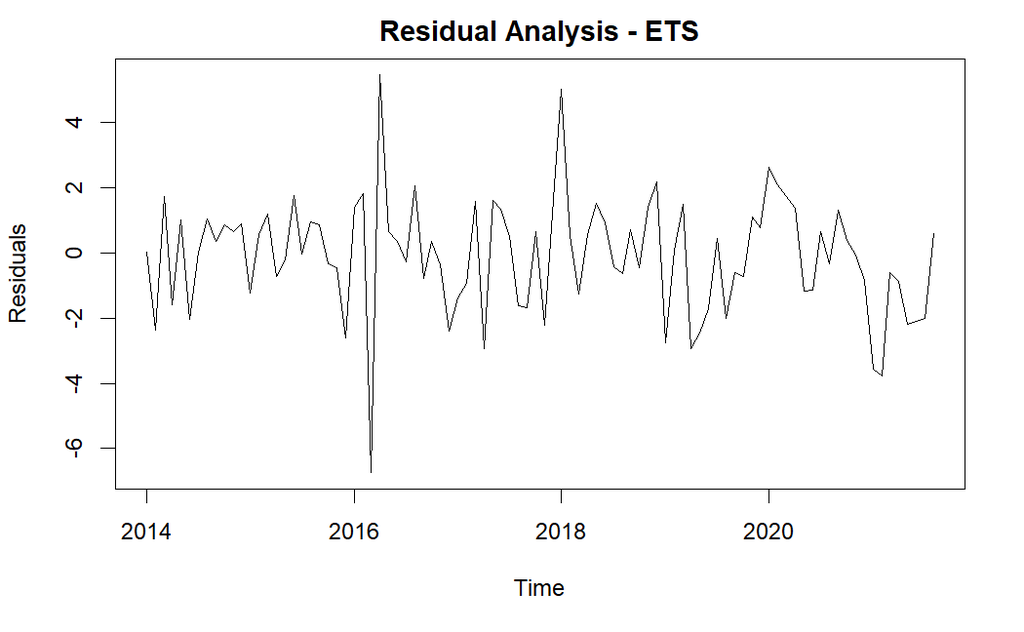

```r
plot(hicp_ets$residuals,main="Residual Analysis - ETS",ylab="Residuals")
```

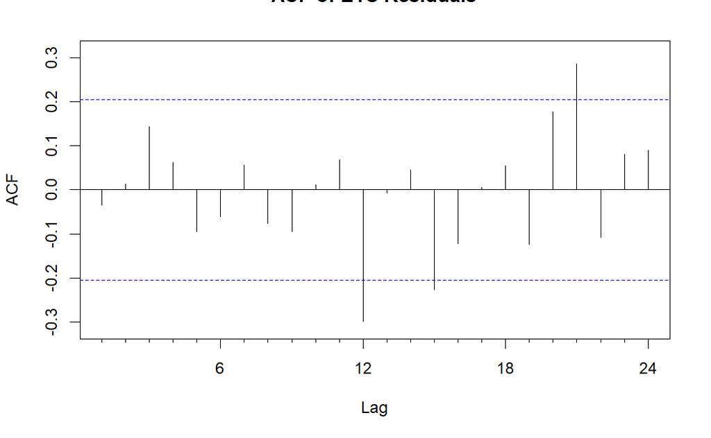

```r
Acf(hicp_ets$residuals,main="ACF of ETS Residuals")
```

Residuals Vs Actual

The residual plot against both fitted and actual values seem random in nature with no recognizable patterns.

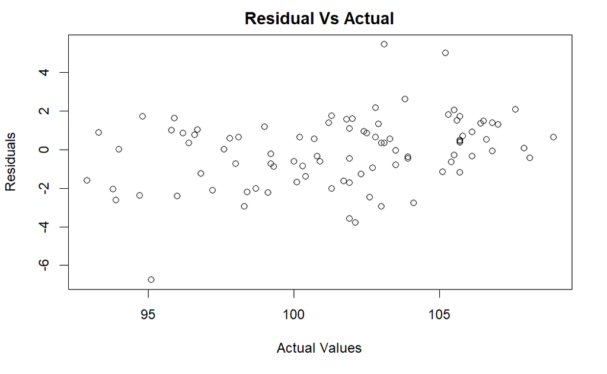

```r
plot(hicp_ets$x,hicp_ets$residuals,xy.labels=FALSE,xy.lines = FALSE,xlab="Actual Values",ylab="Residuals", main="Residual Vs Actual")
```

Residuals Vs Fitted

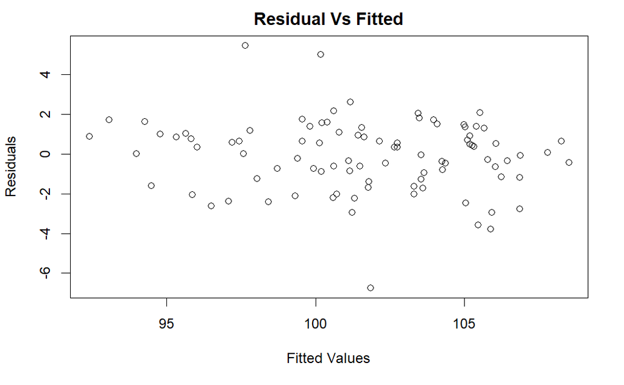

```r
plot(hicp_ets$fitted,hicp_ets$residuals,xy.labels=FALSE,xy.lines = FALSE,xlab="Fitted Values",ylab="Residuals", main="Residual Vs Fitted")
```

#### Accuracy Measures

Here are the various accuracy measures for the ETS model. RMSE for ETS seems much better than that of Naive but we can try doing better.

```r
a_ets<-accuracy(hicp_ets)
a_ets
```

```
                      ME     RMSE      MAE        MPE     MAPE      MASE        ACF1
Training set -0.08966673 1.794307 1.375361 -0.1109913 1.363334 0.3559654 -0.03547928
```

### Holt-Winters Forecast

Holt Winters forecast employs various smoothing constants for level, trend and seasonality components and generates a final forecast equation.Since it takes into consideration all the factors in a time series, we can expect a much better prediction.

```r
hicp_hw <- HoltWinters(hicp_ts_recent)
hicp_hw
```

```
Holt-Winters exponential smoothing with trend and additive seasonal component.

Call:
HoltWinters(x = hicp_ts_recent)

Smoothing parameters:
 alpha: 0.6082252
 beta : 0.04712925
 gamma: 0.2289245

Coefficients:
            [,1]
a   96.972128412
b   -0.263885706
s1  -0.004041357
s2  -0.892865925
s3   0.695216699
s4  -4.660934546
s5  -0.570596751
s6   2.153203896
s7  -0.454343011
s8  -1.147626398
s9  -0.638168293
s10  0.349795445
s11  2.488377664
s12  0.499494634
```

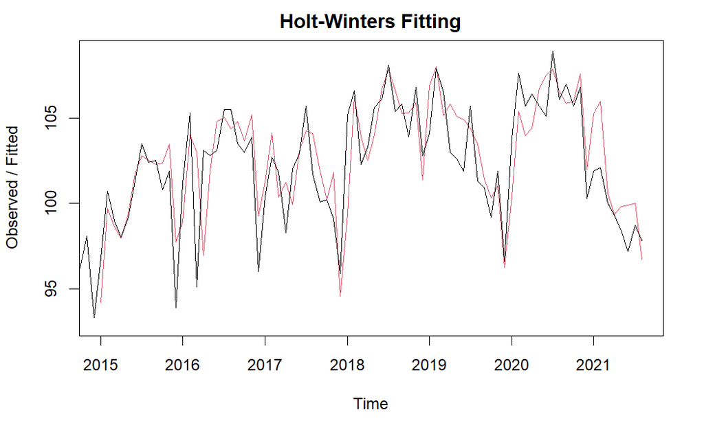

```r
plot(hicp_hw,main="Holt-Winters Fitting")
```

Forecasting using Holt-Winters :

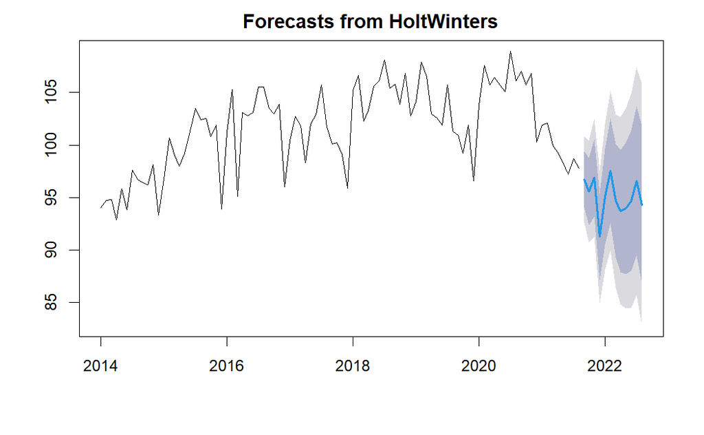

```r
forecast_hw <- forecast(hicp_hw,h=12)
plot(forecast_hw)
```

```r
forecast_hw$mean
```

```
          Jan      Feb      Mar      Apr      May      Jun      Jul      Aug      Sep
2021                                                                         96.70420
2022 95.08210 97.54202 94.67059 93.71342 93.95899 94.68307 96.55776 94.30499
          Oct      Nov      Dec
2021 95.55149 96.87569 91.25565
2022
```

We can see Holt Winters predicting further decrease in the HICP value over the coming year.

#### Residual Analysis for Holt-Winters

Residual Plot

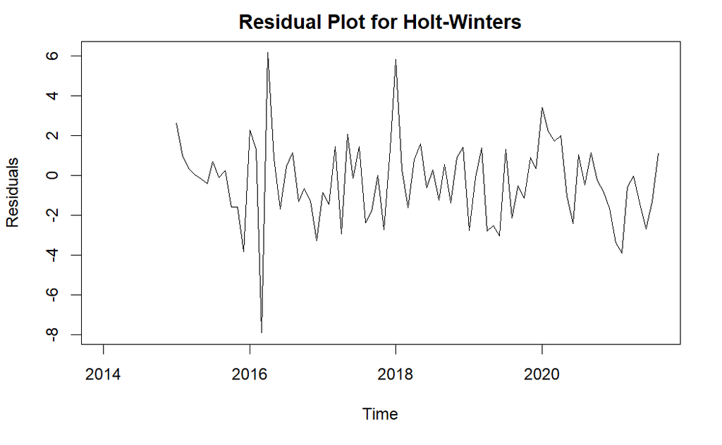

```r
plot(forecast_hw$residuals,main="Residual Plot for Holt-Winters",ylab="Residuals")
```

ACF of Residuals

The ACF looks much better than previous Naive or ETS. We can see there are no significant lags in the ACF anymore and thus we can be sure that the errors are not correlated.

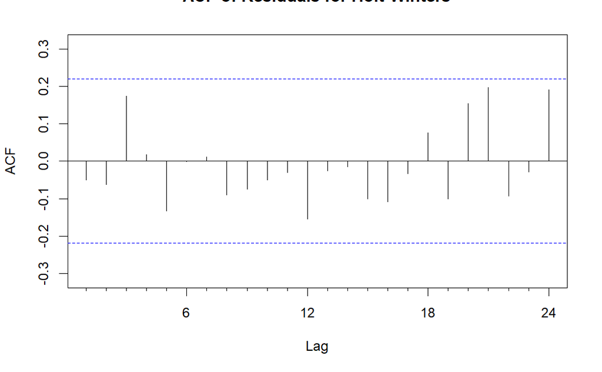

```r
Acf(forecast_hw$residuals, main="ACF of Residuals for Holt-Winters")
```

Histogram of Residuals:

Errors are fairly normally distributed around 0.

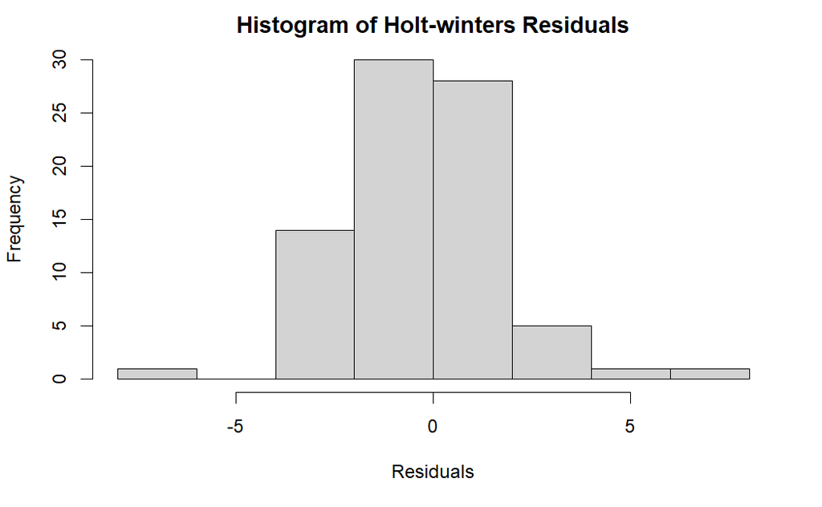

```r
hist(forecast_hw$residuals, main="Histogram of Holt-winters Residuals",xlab="Residuals")
```

Residuals Vs Fitted

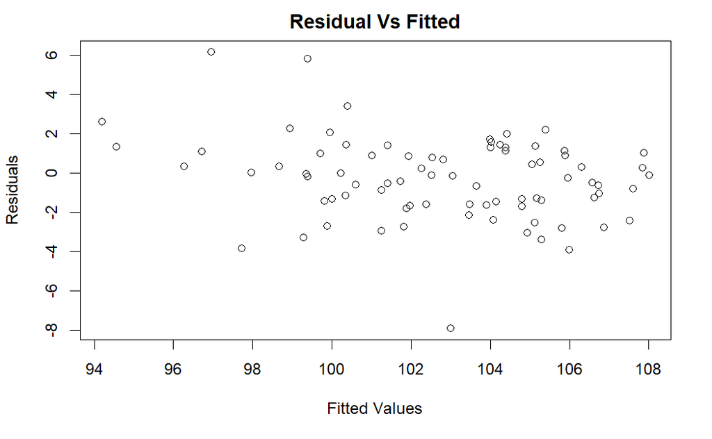

```r
plot(forecast_hw$fitted,forecast_hw$residuals,xy.labels=FALSE,xy.lines = FALSE,xlab="Fitted Values",ylab="Residuals", main="Residual Vs Fitted")
```

Residuals Vs Actual

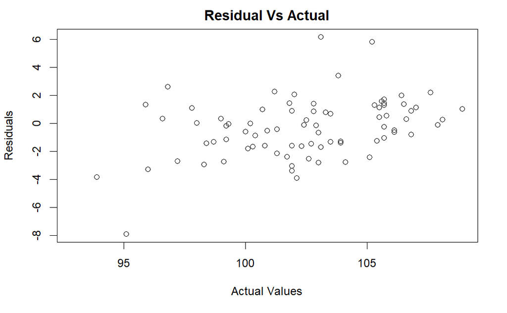

```r
plot(forecast_hw$x,forecast_hw$residuals,xy.labels=FALSE,xy.lines = FALSE,xlab="Actual Values",ylab="Residuals", main="Residual Vs Actual")
```

#### Accuracy Measures

We can see that the RMSE value for Holt-Winters model is better than Naive but slightly worse than ETS, but the ACF of residuals in case of ETS showed some significant correlation. So we would recommend Holt-Winters model over ETS for our forecasting, even though the RMSE measure for ETS is slightly better.

```r
a_hw<-accuracy(forecast_hw)
a_hw
```

```
                     ME     RMSE      MAE        MPE     MAPE      MASE       ACF1
Training set -0.3041817 2.109948 1.591239 -0.3230801 1.566045 0.4118379 -0.0501414
```

```r
sqrt(mean(hicp_hw$SSE))
```

```
[1] 18.87195
```

### Simple Moving Averages

Simple moving average is a simple analysis tool that smooths out the data by creating a constantly updated average price.The degree of smoothing depends on the order of the averages being taken.

For order=3,6 and 9

```r
MA3_hicp <- ma(hicp_ts_recent,order=3)
MA6_hicp <- ma(hicp_ts_recent,order=6)
MA9_hicp <- ma(hicp_ts_recent,order=9)

plot(hicp_ts_recent,ylab="HICP Norway",main="Time Series Plot for HICP - Norway",col="Grey",lwd=1.5)
lines(MA3_hicp, col = "Dark Red",lwd=1.5)
```

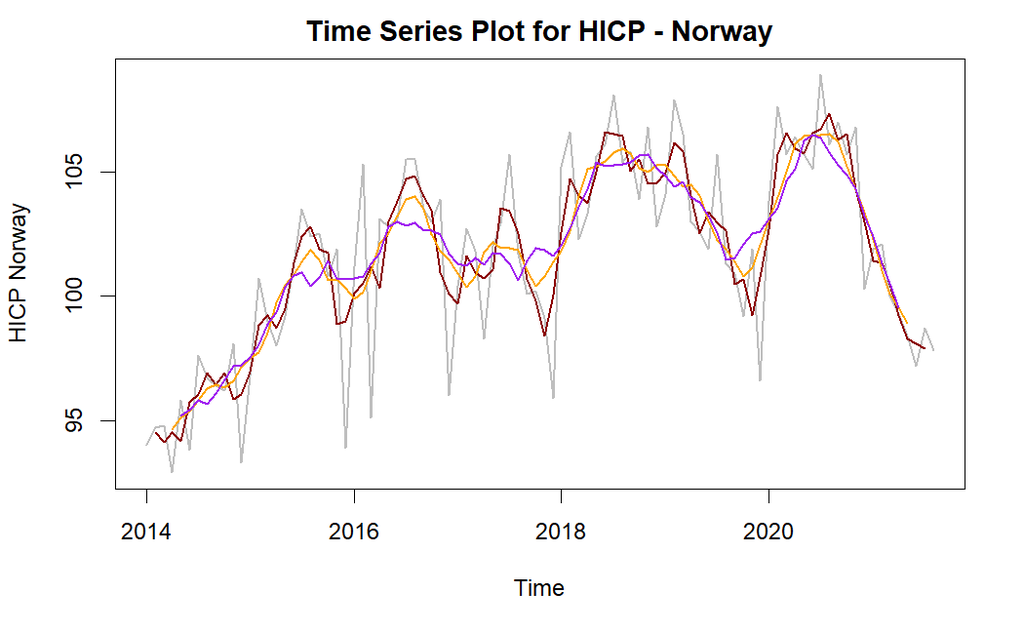

```r
lines(MA6_hicp, col = "Orange",lwd=1.5)
lines(MA9_hicp, col = "Purple",lwd=1.5)
```

Looking at the graph, we believe that moving averages with order 6 would be the best choice for prediction here as we are doing a long range prediction into the next year.